# Sismos en el Perú de los últimos 60 años (Entregable 2)

Franco Bocangel

12-05-2024

# Paso 1. Importar archivo de sismos en .xlsx

Para comenzar, importaremos el archivo de sismos en formato Excel para comenzar nuestro análisis. Utilizaremos el paquete `readxl` para leer el archivo.

```r
install.packages("readxl", repos = "https://cran.rstudio.com/")
library(readxl)

# Cargar los datos desde el archivo Excel
datos_sismicos <- read_excel("Catalogo1960_2023.xlsx")
```

## Paso 2. Entender la base de datos

A continuación, examinaremos la estructura y el contenido de la base de datos para comprender mejor los datos con los que estamos trabajando.

```r
# Visualizar las primeras filas del conjunto de datos
head(datos_sismicos)
```

```
## # A tibble: 6 × 8
##      ID FECHA_UTC HORA_UTC LATITUD LONGITUD PROFUNDIDAD MAGNITUD FECHA_CORTE
##   <dbl>     <dbl> <chr>      <dbl>    <dbl>       <dbl>    <dbl>       <dbl>
## 1     0  19600113 154034     -16.1    -72.1          60      7.5    20223006
## 2     1  19600115 093024     -15      -75            70      7      20223006
## 3     2  19600117 025758     -14.5    -74.5         150      6.4    20223006
## 4     3  19600123 033732     -12.5    -68.5         300      5.8    20223006
## 5     4  19600130 050724      -5.5    -77.5         100      5.7    20223006
## 6     5  19600208 190616      -8.5    -74.5         136      5.3    20223006
```

```r
# Resumen estadístico de las variables numéricas
summary(datos_sismicos)
```

```
##        ID          FECHA_UTC          HORA_UTC            LATITUD
##  Min.   :    0   Min.   :19600113   Length:23680       Min.   :-23.40
##  1st Qu.: 5920   1st Qu.:19950214   Class :character   1st Qu.:-15.38
##  Median :11840   Median :20060809   Mode  :character   Median :-11.71
##  Mean   :11840   Mean   :20031565                      Mean   :-11.37
##  3rd Qu.:17759   3rd Qu.:20150510                      3rd Qu.: -7.91
##  Max.   :23679   Max.   :20231231                      Max.   : -1.49
##     LONGITUD       PROFUNDIDAD       MAGNITUD      FECHA_CORTE
##  Min.   :-82.89   Min.   :  0.0   Min.   :3.000   Min.   :20223006
##  1st Qu.:-77.77   1st Qu.: 29.0   1st Qu.:4.500   1st Qu.:20223006
##  Median :-75.74   Median : 48.0   Median :4.700   Median :20223006
##  Mean   :-75.70   Mean   : 71.1   Mean   :4.722   Mean   :20223532
##  3rd Qu.:-73.60   3rd Qu.:106.0   3rd Qu.:4.900   3rd Qu.:20223006
##  Max.   :-66.98   Max.   :743.0   Max.   :8.400   Max.   :20240101
```

Añadiremos algunos gráficos exploratorios para comprender mejor nuestros datos.

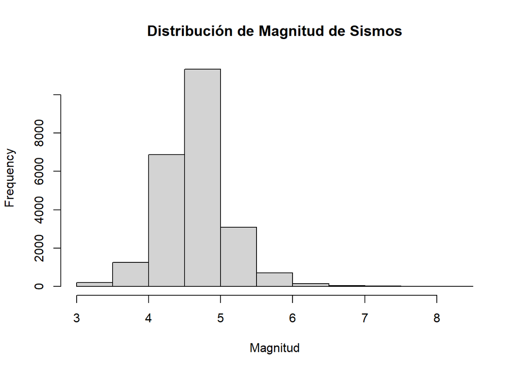

```r
# Histograma de Magnitudes
hist(datos_sismicos$MAGNITUD, main = "Distribución de Magnitud de Sismos", xlab = "Magnitud")
```

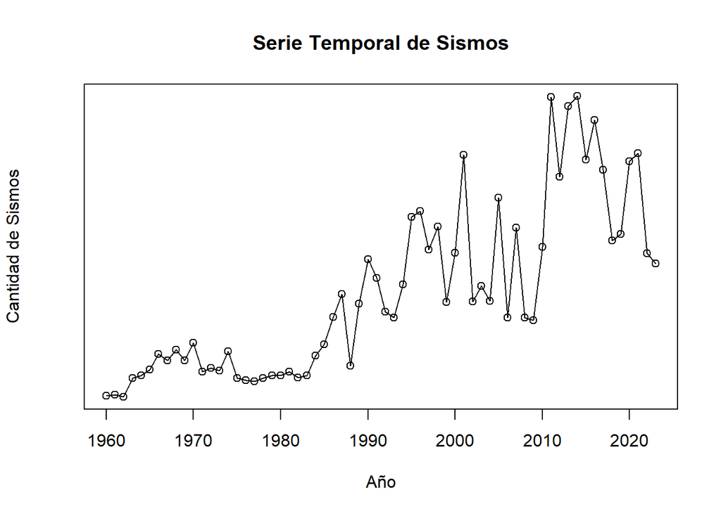

```r
# Contar la cantidad de sismos por año
datos_sismicos$FECHA_UTC <- as.Date(as.character(datos_sismicos$FECHA_UTC), format = "%Y%m%d")
sismos_por_anio <- table(format(datos_sismicos$FECHA_UTC, "%Y"))

# Graficar la serie temporal de sismos
plot(as.numeric(names(sismos_por_anio)), sismos_por_anio,
     type = "o", xlab = "Año", ylab = "Cantidad de Sismos",
     main = "Serie Temporal de Sismos")
```

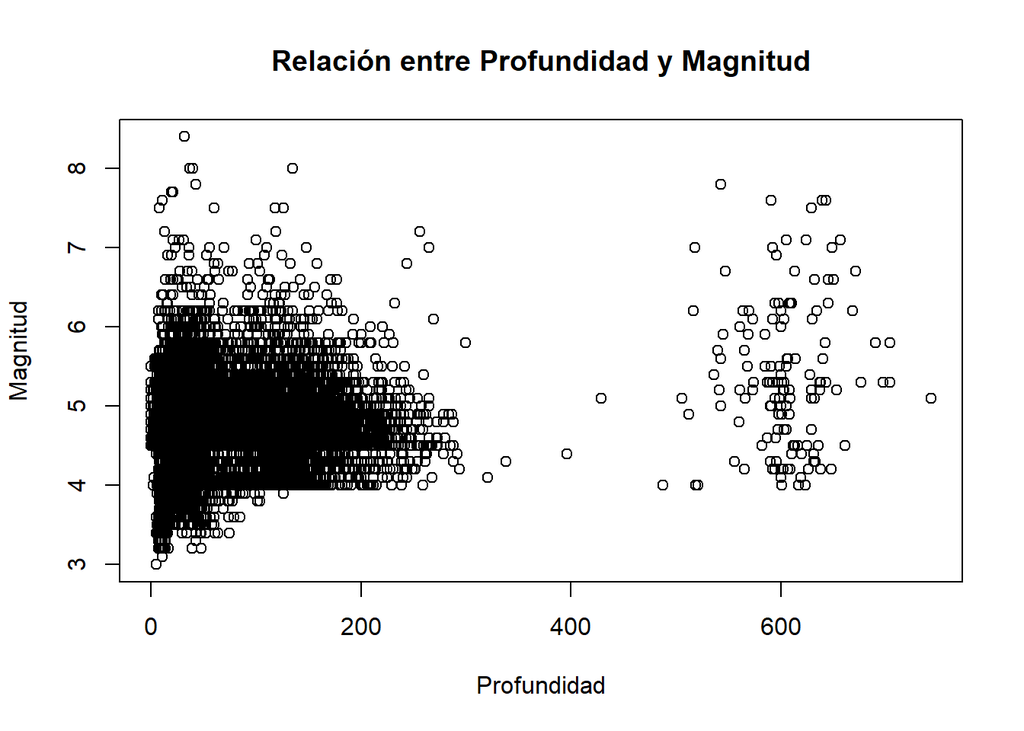

```r
# Diagrama de Dispersión de Profundidad vs. Magnitud
plot(datos_sismicos$PROFUNDIDAD, datos_sismicos$MAGNITUD,
     xlab = "Profundidad", ylab = "Magnitud",
     main = "Relación entre Profundidad y Magnitud")
```

## Paso 3. Generar regresión lineal

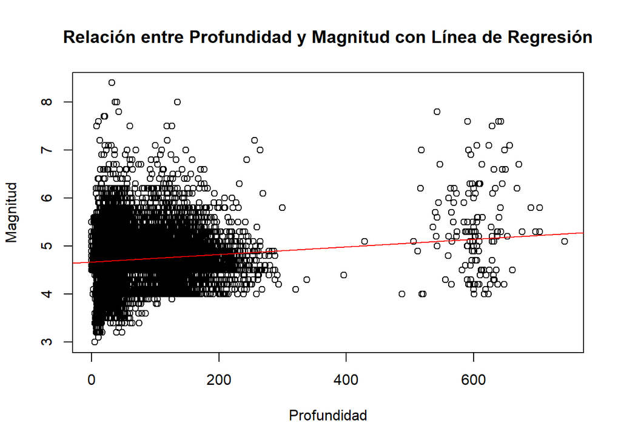

```r
# Modelo Predictivo: Regresión Lineal
modelo <- lm(MAGNITUD ~ PROFUNDIDAD, data = datos_sismicos)

# Visualización del Modelo: Diagrama de Dispersión con Línea de Regresión
plot(datos_sismicos$PROFUNDIDAD, datos_sismicos$MAGNITUD,
     xlab = "Profundidad", ylab = "Magnitud",
     main = "Relación entre Profundidad y Magnitud con Línea de Regresión")
abline(modelo, col = "red")
```

## Paso 4. Evaluar, y en caso necesario, ajustar la regresión lineal

A continuación, evaluaremos el modelo de regresión lineal y ajustaremos si es necesario.

```r
# Resumen del modelo
summary(modelo)
```

```
##
## Call:
## lm(formula = MAGNITUD ~ PROFUNDIDAD, data = datos_sismicos)
##
## Residuals:
##     Min      1Q  Median      3Q     Max
## -1.6698 -0.2022 -0.0730  0.2041  3.7088
##
## Coefficients:
##              Estimate Std. Error t value Pr(>|t|)
## (Intercept) 4.666e+00  4.147e-03 1125.24   <2e-16 ***
## PROFUNDIDAD 7.910e-04  4.267e-05   18.54   <2e-16 ***
## ---
## Signif. codes:  0 '***' 0.001 '**' 0.01 '*' 0.05 '.' 0.1 ' ' 1
##
## Residual standard error: 0.4349 on 23678 degrees of freedom
## Multiple R-squared:  0.0143, Adjusted R-squared:  0.01426
## F-statistic: 343.6 on 1 and 23678 DF,  p-value: < 2.2e-16
```

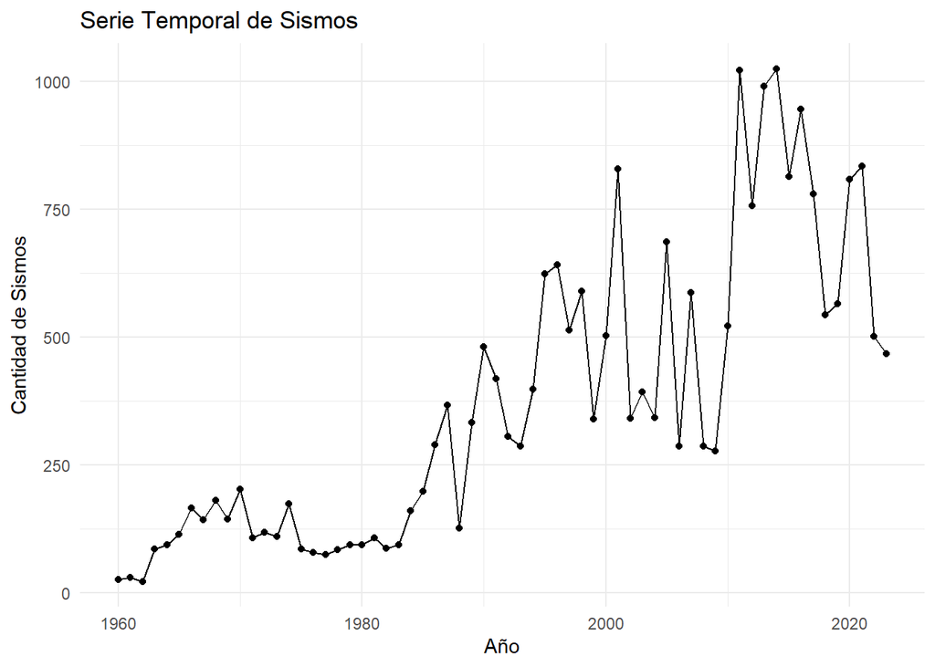

```r
# Instalamos y cargamos el paquete necesario
# Set a CRAN mirror
chooseCRANmirror(ind = 1)

# Install the necessary package
install.packages("ggplot2")
# Load the library
library(ggplot2)


# Convertimos la tabla a dataframe
df_sismos_por_anio <- data.frame(Año = as.numeric(names(sismos_por_anio)), Sismos = as.numeric(sismos_por_anio))

# Graficamos la serie temporal de sismos con ggplot2
ggplot(data = df_sismos_por_anio, aes(x = Año, y = Sismos)) +
  geom_line() +
  geom_point() +
  labs(x = "Año", y = "Cantidad de Sismos", title = "Serie Temporal de Sismos") +
  theme_minimal()
```

## Paso 6. Conclusiones

Después de realizar el análisis de los datos de sismos en el Perú, hemos llegado a las siguientes conclusiones:

Modelo de Regresión Lineal: Desarrollamos un modelo de regresión lineal para predecir la magnitud de los sismos basándonos en la profundidad. Si bien el modelo mostró una relación significativa entre estas variables, es importante tener en cuenta que la predicción de la magnitud de un sismo puede ser un desafío debido a la complejidad de los procesos geológicos involucrados.

Evaluación del Modelo: Al evaluar nuestro modelo de regresión lineal, observamos cierta variabilidad en las predicciones, lo que sugiere que podría haber otros factores influyendo en la magnitud de los sismos que no están incluidos en nuestro modelo. Esto indica la necesidad de investigar y considerar otras variables relevantes en futuros análisis.

Perspectivas Futuras: Para futuros estudios, sería beneficioso explorar otras variables que podrían influir en la magnitud de los sismos, como la ubicación geográfica, la actividad tectónica regional y la composición del suelo. Además, se podría considerar el uso de modelos más avanzados, como técnicas de aprendizaje automático, para mejorar la precisión de las predicciones de magnitud de los sismos.